*Joaquin, Marc Christopher C.*  
*58010*  
*Engr. Dylan Lopez*

# Linear Algebra for CpE

## Laboratory 4 : Vector Operations

Now that you have a fundamental knowledge about linear combination, we'll try to apply the fundamental operations

### Objectives

At the end of this activity you will be able to:

1. Referesh knowledge on vector operations while being familiar with new operations such as products.
2. Visualize vector operations.
3. Perform vector operations using Python.

## Discussion

```python
import numpy as np
import matplotlib.pyplot as plt
%matplotlib inline
```

We have dealt with some of the vector operations in the last module, now we will dwell into more operations. In this laboratory, we will tackle addition,multiplication,division and the inner product of a vector.

## Vector Addition

So if do a vector addition of these two vectors we'll get:

$$A + B = \begin{bmatrix}4\\3\\-2\end{bmatrix}$$

We can progammatically solve this using `np.add()` or simply using `+`.

```python
A = np.array([1,2,0])
B = np.array([3,1,-2])
```

```python
A+B
```

```
array([ 4,  3, -2])
```

```python
np.add(A,B)
```

```
array([ 4,  3, -2])
```

## Vector Subtraction

Vector subtraction is similar to your vector addition but you would need to scale the second vector using a negative scalar that is usuall $-1$. So if we subtract vector $B$ from vector $A$ we get:

$$A-B = \begin{bmatrix}-2\\1\\2\end{bmatrix}$$

In Python, this can be achieved by using `np.subtract()` or `-`

```python
np.subtract(A,B)
```

```
array([-2,  1,  2])
```

```python
A-B
```

```
array([-2,  1,  2])
```

## Vector Multiplication

Vector multiplication, like addition does its operations element-wise. So basic vector multiplication can be achieved by multiplying the elements or the scalars of the vectors individually. So: $$A * B = \begin{bmatrix}3\\2\\0\end{bmatrix}$$ We can implement this in code by using `np.multiply()` or simply operating with `*`.

```python
np.multiply(A,B)
```

```
array([3, 2, 0])
```

```python
A*B
```

```
array([3, 2, 0])
```

## Vector Division

Dividing a vector by another is uncommon, but if the situation specifies that each elements or scalars of the vector would be divided individually we can perform this by: $$A./B = \begin{bmatrix}\frac{1}{3}\\2\\0\end{bmatrix}$$ Take note that the notation we used here is $./$ for element-wise division, this notation is based in a MATLab notation for element-wise division. This can be achieved in Python using `np.divide()` or `/`.

```python
np.divide(A,B)
```

```
array([ 0.33333333,  2.        , -0.        ])
```

```python
A/B
```

```
array([ 0.33333333,  2.        , -0.        ])
```

## Modulus of a Vector

The modulus of a vector or the magnitude of a vector can be determined using the Pythagorean theorem. Given the vector $A$ and its scalars denoted as $a_n$ where $n$ is the index of the scalar. So if we have: $$A = \begin{bmatrix}1\\2\end{bmatrix}$$ We can compute the magnitude as: $$||A|| = \sqrt{a_1^2 + a_2^2} = \sqrt{1^2 + 2^2} = \sqrt{5}$$ So if we have a matrix with more parameters such as: $$B=\begin{bmatrix}2\\5\\-1\\0\end{bmatrix}$$ We can generalize the Pythagorean theorem to compute for the magnitude as: $$||B|| = \sqrt{b_1^2 + b_2^2 + b_3^2 + ... +b_n^2} = \sqrt{\sum_{n=1}^{N}b_n^2}$$ And this equation is now called a Euclidian distance or the Euclidean Norm. We can implement this explicitly by for loops or using `np.linalg.norm()` to get the Euclidian Norm.

```python
A = np.array([1,2])
B = np.array([2,5,-1,0])
#C = np.array([2,9,10,3])
```

```python
np.linalg.norm(A)
```

[output not shown]

```python
np.linalg.norm(B)
```

```
5.477225575051661
```

## Vector Dot Product / Inner Product

```python
H = np.array([1,3,6])
G = np.array([5,2,1])
```

```python
np.inner(H,G)
```

```
17
```

```python
H @ G
```

```
17
```

## Activity

### Task 1

Make an explicit function (not using any of NumPy's preset functions) solving the modulus of a vector using the Euclidian Norm formula: $$||X|| = \sqrt{\sum_{n=1}^{N}x_n^2}$$ Create a program flowchart for your algorithm and explain it in your methodology. Create 6 different vectors which their element count should not be lower than 4 elements. Explain the results at the results discussion section while comparing them to the `np.linalg.norm()` function.

```python
#Using my Explicit Function

import math

#Lists of every vectors
VectA = (3,7,1,10)
VectB = (4,5,3,7)
VectC = (8,2,4,1)
VectD = (7,1,2,5)
VectE = (3,5,6,4)
VectF = (2,9,10,3)


#Multiply each element by itself
Vect_A = ((VectA[0] * VectA[0]) + (VectA[1] * VectA[1]) + (VectA[2] * VectA[2]) + (VectA[3] * VectA[3]))
Vect_B = ((VectB[0] * VectB[0]) + (VectB[1] * VectB[1]) + (VectB[2] * VectB[2]) + (VectB[3] * VectB[3]))
Vect_C = ((VectC[0] * VectC[0]) + (VectC[1] * VectC[1]) + (VectC[2] * VectC[2]) + (VectC[3] * VectC[3]))
Vect_D = ((VectD[0] * VectD[0]) + (VectD[1] * VectD[1]) + (VectD[2] * VectD[2]) + (VectD[3] * VectD[3]))
Vect_E = ((VectE[0] * VectE[0]) + (VectE[1] * VectE[1]) + (VectE[2] * VectE[2]) + (VectE[3] * VectE[3]))
Vect_F = ((VectF[0] * VectF[0]) + (VectF[1] * VectF[1]) + (VectF[2] * VectF[2]) + (VectF[3] * VectF[3]))

#Use sqrt() function by math
E_dista = math.sqrt(Vect_A)
E_distb = math.sqrt(Vect_B)
E_distc = math.sqrt(Vect_C)
E_distd = math.sqrt(Vect_D)
E_diste = math.sqrt(Vect_E)
E_distf = math.sqrt(Vect_F)

#Print all the values
print("The Euclidean distance of Vector A is: ", E_dista)
print("The Euclidean distance of Vector B is: ", E_distb)
print("The Euclidean distance of Vector C is: ", E_distc)
print("The Euclidean distance of Vector D is: ", E_distd)
print("The Euclidean distance of Vector E is: ", E_diste)
print("The Euclidean distance of Vector F is: ", E_distf)
```

```
The Euclidean distance of Vector A is:  12.609520212918492
The Euclidean distance of Vector B is:  9.9498743710662
The Euclidean distance of Vector C is:  9.219544457292887
The Euclidean distance of Vector D is:  8.888194417315589
The Euclidean distance of Vector E is:  9.273618495495704
The Euclidean distance of Vector F is:  13.92838827718412
```

```python
#Proof
import numpy as np

Vecta = np.array([3,7,1,10])
Vectb = np.array([4,5,3,7])
Vectc = np.array([8,2,4,1])
Vectd = np.array([7,1,2,5])
Vecte = np.array([3,5,6,4])
Vectf = np.array([2,9,10,3])

P_Va = np.linalg.norm(Vecta)
P_Vb = np.linalg.norm(Vectb)
P_Vc = np.linalg.norm(Vectc)
P_Vd = np.linalg.norm(Vectd)
P_Ve = np.linalg.norm(Vecte)
P_Vf = np.linalg.norm(Vectf)

print("The Euclidean distance of Vector A with Numpy is: ", P_Va)
print("The Euclidean distance of Vector A with Numpy is: ", P_Vb)
print("The Euclidean distance of Vector A with Numpy is: ", P_Vc)
print("The Euclidean distance of Vector A with Numpy is: ", P_Vd)
print("The Euclidean distance of Vector A with Numpy is: ", P_Ve)
print("The Euclidean distance of Vector A with Numpy is: ", P_Vf)
```

```
The Euclidean distance of Vector A with Numpy is:  12.609520212918492
The Euclidean distance of Vector A with Numpy is:  9.9498743710662
The Euclidean distance of Vector A with Numpy is:  9.219544457292887
The Euclidean distance of Vector A with Numpy is:  8.888194417315589
The Euclidean distance of Vector A with Numpy is:  9.273618495495704
The Euclidean distance of Vector A with Numpy is:  13.92838827718412
```

### Task 2

Make an explicit function (not using any of NumPy's preset functions nor the `@` operator) solving the inner product of two vectors using the inner product formula: $$A\cdot B = \sum_{n=1}^{N} a_n \times b_n $$ $$whereas: N = len(A) = len(B)$$ Create a program flowchart for your algorithm and explain it in your methodology. Create 5 distinct pairs vectors which their element count should not be lower than 5 elements. Explain the results at the results discussion section while comparing them to the `np.inner()` function.

```python
#Using my explicit function

import math

#Pair 1
LetterA = (4,5,1,2,3)
LetterB = (8,2,7,1,4)

#Pair 2
LetterC = (1,2,3,4,5)
LetterD = (6,7,8,9,1)

#Pair 3
LetterE = (1,3,5,7,9)
LetterF = (2,4,6,8,0)

#Pair 4
LetterG = (1,5,7,9,3)
LetterH = (5,6,7,9,4)

#Pair 5
LetterI = (9,4,2,1,4)
LetterJ = (4,5,8,3,1)

#Multiplying each element of every pair.
A_B = ((LetterA[0]*LetterB[0]) + (LetterA[1]*LetterB[1]) + (LetterA[2]*LetterB[2]) + (LetterA[3]*LetterB[3]) + (LetterA[4]*LetterB[4]))
C_D = ((LetterC[0]*LetterD[0]) + (LetterC[1]*LetterD[1]) + (LetterC[2]*LetterD[2]) + (LetterC[3]*LetterD[3]) + (LetterC[4]*LetterD[4]))
E_F = ((LetterE[0]*LetterF[0]) + (LetterE[1]*LetterF[1]) + (LetterE[2]*LetterF[2]) + (LetterE[3]*LetterF[3]) + (LetterE[4]*LetterF[4]))
G_H = ((LetterG[0]*LetterH[0]) + (LetterG[1]*LetterH[1]) + (LetterG[2]*LetterH[2]) + (LetterG[3]*LetterH[3]) + (LetterG[4]*LetterH[4]))
I_J = ((LetterI[0]*LetterJ[0]) + (LetterI[1]*LetterJ[1]) + (LetterI[2]*LetterJ[2]) + (LetterI[3]*LetterJ[3]) + (LetterI[4]*LetterJ[4]))

print("The dot product of Letter A and Letter B is: ", A_B)
print("The dot product of Letter C and Letter D is: ", C_D)
print("The dot product of Letter E and Letter F is: ", E_F)
print("The dot product of Letter G and Letter H is: ", G_H)
print("The dot product of Letter I and Letter J is: ", I_J)
```

```
The dot product of Letter A and Letter B is:  63
The dot product of Letter C and Letter D is:  85
The dot product of Letter E and Letter F is:  100
The dot product of Letter G and Letter H is:  177
The dot product of Letter I and Letter J is:  79
```

```python
#Proof
import numpy as np

letterA = np.array([4,5,1,2,3])
letterB = np.array([8,2,7,1,4])

letterC = np.array([1,2,3,4,5])
letterD = np.array([6,7,8,9,1])

letterE = np.array([1,3,5,7,9])
letterF = np.array([2,4,6,8,0])

letterG = np.array([1,5,7,9,3])
letterH = np.array([5,6,7,9,4])

letterI = np.array([9,4,2,1,4])
letterJ = np.array([4,5,8,3,1])

print("The dot product of Letter A and Letter B using Numpy is: ", np.inner(letterA,letterB))
print("The dot product of Letter C and Letter D using Numpy is: ", np.inner(letterC,letterD))
print("The dot product of Letter E and Letter F using Numpy is: ", np.inner(letterE,letterF))
print("The dot product of Letter G and Letter H using Numpy is: ", np.inner(letterG,letterH))
print("The dot product of Letter I and Letter J using Numpy is: ", np.inner(letterI,letterJ))
```

```
The dot product of Letter A and Letter B using Numpy is:  63
The dot product of Letter C and Letter D using Numpy is:  85
The dot product of Letter E and Letter F using Numpy is:  100
The dot product of Letter G and Letter H using Numpy is:  177
The dot product of Letter I and Letter J using Numpy is:  79
```

### Task 3

Create a program flowchart for your algorithm and explain it in your methodology. In your results, compare your answer to the expected output, visualize, and explain the resulting vector using a 3D plot.

```python
import numpy as np
A = np.array([-0.4,0.3,-0.6])
B = np.array([-0.2,0.2,1])
C = np.array([0.2,0.1,-0.5])

square = (A*A, B*B, C*C)
first_eq = np.sum(square)
mul = A*B
Total = np.add(B,mul)
Mul = np.multiply(A,Total)
second_eq = np.divide(Mul,C)
total = np.add(A,B)
third_eq = np.linalg.norm(np.add(total,C))

Times = np.multiply(first_eq, second_eq)
overall = np.multiply(Times,third_eq)

print(overall)
```

```
[0.34769805 1.13001866 0.6953961 ]
```

Expected answer:  
`array([0.34769805, 1.13001866, 0.6953961 ])`

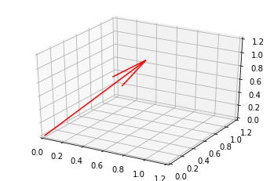

```python
fig = plt.figure()
ax = fig.gca(projection='3d')
ax.quiver(0, 0, 0, final[0], final[1], final[2], colors='r')
ax.set_xlim([0, 1.2])
ax.set_ylim([0, 1.2])
ax.set_zlim([0, 1.2])
plt.show()
```

## Conclusion guide

For your conclusion synthesize the concept and application of the laboratory. Briefly discuss what you have learn and achieved in this activity.